# Praca domowa 2

Jagna Wnuk

## Dane

Dane wykorzystane w Pracy domowej 2 dotyczą wyników egzaminów z 3 umiejętności: czytania, pisania i operacji matematycznych. Dodatkowo dostępne są podstawowe informacje o studentach i ich rodzicach. Opis wszystkich kolumn znajduje się również w pliku `README.md`.

| Zmienna | Opis |
| --- | --- |
| **gender** | płeć |
| **race.ethnicity** | pochodzenie etniczne |
| **parental.level.of.education** | wykształcenie rodziców |
| **lunch** | jaki obiad jedli uczniowie w dniu egzaminu |
| **test.preparation.course** | czy uczeń odbył kurs przygotowujący |
| **math.score** | wynik egzaminu z matematyki |
| **reading.score** | wynik egzaminu z czytania |
| **writing.score** | wynik egzaminu z pisania |

## Zadanie 1

Jak wyglądają rozkłady wyników uczniów z trzech przedmiotów (matematyka, czytanie, pisanie)?

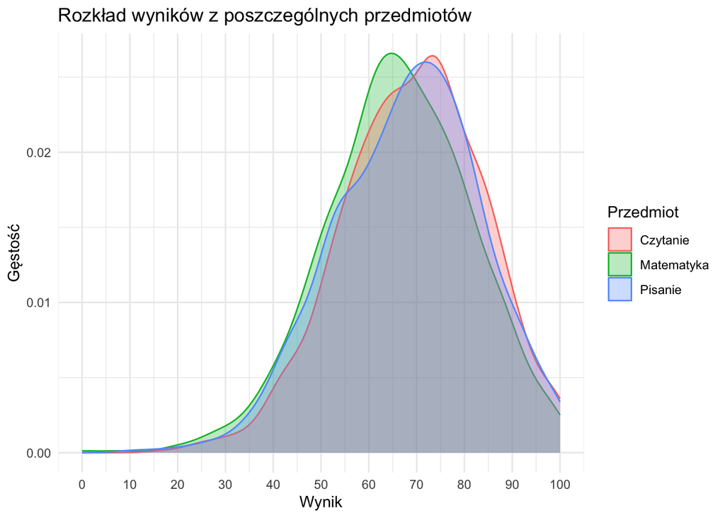

```r
ggplot() +
  geom_density(data = df, aes(x = math.score, color = "Matematyka", fill = "Matematyka"), alpha = 0.3) +
  geom_density(data = df, aes(x = reading.score, color = "Czytanie", fill = "Czytanie"), alpha = 0.3) +
  geom_density(data = df, aes(x = writing.score, color = "Pisanie", fill = "Pisanie"), alpha = 0.3) +
  labs(
    title = "Rozkład wyników z poszczególnych przedmiotów",
    x = "Wynik",
    y = "Gęstość",
    color = "Przedmiot",
    fill = "Przedmiot"
  ) +
  scale_x_continuous(limits = c(0, 100), breaks = seq(0, 100, by = 10))+
  theme(title = element_text(size = 10)) +
  theme_minimal()
```

**Rozkłady wyników uczniów z matematyki, czytania i pisania są do siebie bardzo podobne, przypominają rozkład normalny. Wszystkie trzy przedmioty mają największa gęstość w przedziale ok. 65–75 punktów, co świadczy o podobnym poziomie trudności i ogólnych osiągnięć uczniów. Chociaż rozkład wyników z matematyki jest delikatnie przesunięty w w kierunku niższych wyników, a czytanie i pisanie są bardziej zbliżone, to ogólny zakres zmienności wyników jest w zasadzie identyczny dla wszystkich trzech przedmiotów**

## Zadanie 2

Czy istnieje zauważalna różnica w wynikach między uczniami i uczennicami?

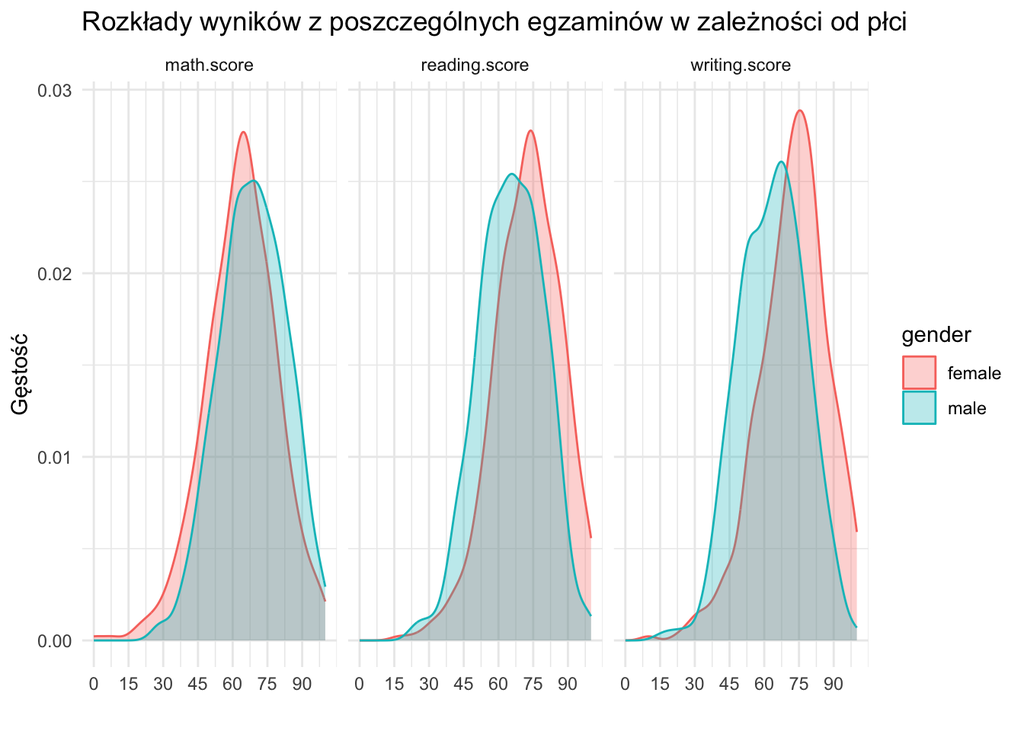

```r
library(tidyr)

df_long <- df %>%
  pivot_longer(
    cols = c(math.score, reading.score, writing.score),
    names_to = "subject",
    values_to = "score"
  )

ggplot(df_long, aes(x = score, color = gender, fill = gender)) +
  geom_density(alpha = 0.3) +
  labs(
    title = "Rozkłady wyników z poszczególnych egzaminów w zależności od płci",
    x = "",
    y = "Gęstość"
  ) +
  scale_x_continuous(limits = c(0, 100), breaks = seq(0, 100, by = 15))+
  scale_y_continuous(limits = c(0, 0.029)) +
  facet_wrap(~ subject) +
  theme(title = element_text(size = 10)) +
  theme_minimal()
```

**Tak istnieje zauważalna różnica. Rozkład wyników mężczyzn z egzaminu z matematyki jest przesunięty w prawo w porównaniu do rozkładu kobiet, co oznacza, że w większości osiągają oni wyższe wyniki niż kobiety. W przypadku egzaminu z czytania i pisania jest odwrotnie, to kobiety osiągają typowo lepsze wyniki.**

## Zadanie 3

Czy uczniowie, którzy ukończyli kurs przygotowawczy, osiągają lepsze wyniki niż pozostali?

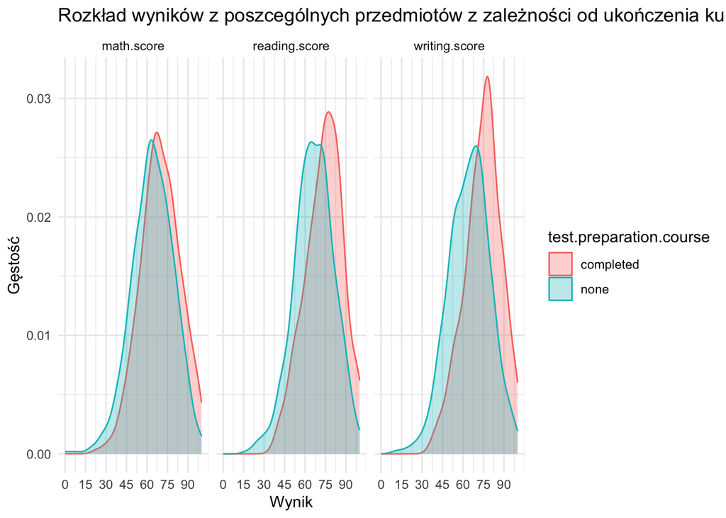

```r
df_long %>%
ggplot() +
  geom_density(aes(x = score, color = test.preparation.course, fill = test.preparation.course), alpha = 0.3) +
  labs(
    title = "Rozkład wyników z poszcególnych przedmiotów z zależności od ukończenia kursu przygotowawczego",
    x = "Wynik",
    y = "Gęstość"
  )+
  scale_x_continuous(limits = c(0, 100), breaks = seq(0, 100, by = 15))+
  facet_wrap(~ subject)+
  theme(title = element_text(size = 8)) +
  theme_minimal()
```

## Zadanie 4

Jaki jest związek między poziomem wykształcenia rodziców a średnimi wynikami uczniów?

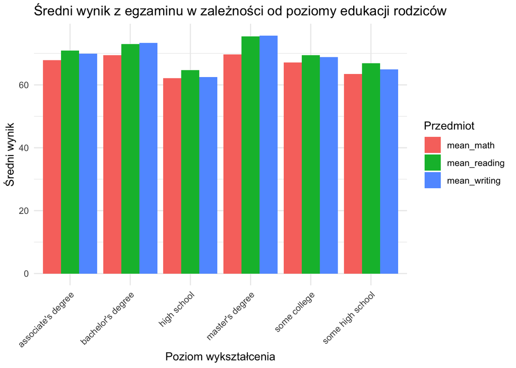

```r
library(tidyr)

df %>%
  group_by(parental.level.of.education) %>%
  summarise(
    mean_math = mean(math.score, na.rm = TRUE),
    mean_reading = mean(reading.score, na.rm = TRUE),
    mean_writing = mean(writing.score, na.rm = TRUE)
  ) %>%
  pivot_longer(
    cols = starts_with("mean_"),
    names_to = "subject",
    values_to = "mean_score"
  ) %>%
  ggplot(aes(x = parental.level.of.education, y = mean_score, fill = subject)) +
  geom_col(position = "dodge") +
  labs(
    title = "Średni wynik z egzaminu w zależności od poziomy edukacji rodziców",
    x = "Poziom wykształcenia",
    y = "Średni wynik",
    fill = "Przedmiot"
  ) +
  theme_minimal() +
  theme(axis.text.x = element_text(angle = 45, hjust = 1))
```

**Uczniowie, których rodzice mają wyższe wykształcenie, takie jak “master’s degree” (magister) czy “bachelor’s degree” (licencjat), osiągają najwyższe średnie wyniki we wszystkich trzech przedmiotach (matematyka, czytanie, pisanie). Najniższe średnie wyniki są obserwowane w grupach, gdzie rodzice mają niższe wykształcenie, np. “some high school” (nieukończone liceum) czy “high school” (liceum).**

## Zadanie 5

Czy płeć i wykształcenie rodzica wpływa na wynik z matematyki?

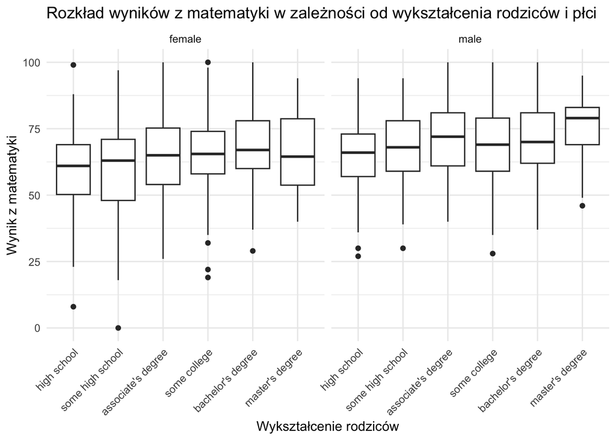

```r
df %>%
  ggplot(aes(x = reorder(parental.level.of.education, math.score, FUN = median), y = math.score)) +
  geom_boxplot() +
  labs(
    title = "Rozkład wyników z matematyki w zależności od wykształcenia rodziców i płci",
    x = "Wykształcenie rodziców",
    y = "Wynik z matematyki"
  ) +
  facet_wrap(~ gender) +
  theme_minimal() +
  theme(axis.text.x = element_text(angle = 45, hjust = 1))
```

## Zadanie 6

Czy istnieje zależność między wynikami z matematyki a wynikami z czytania lub pisania?

[figure not shown]

```r
df %>%
  select(math.score, reading.score, writing.score) %>%
  pivot_longer(cols = c(reading.score, writing.score), values_to = "score") %>%
  ggplot(aes(x = math.score)) +
  geom_point(aes(y = score), alpha = 0.6) +
  labs(
    title = "Zależność wyniku z matematyki od wyniku z czytania i pisania",
    x = "",
    y = "wynik z matematyki",
    colour = "Rodzaj wyniku"
  ) +
  facet_wrap(~ name)
```

**Uczeń osiągający dobry wynik w matematyce zazwyczaj ma również wysokie wyniki w czytaniu i pisaniu, a uczniowie z niskimi wynikami z matematyki mają również słabe rezultaty w tych dwóch pozostałych dziedzinach. Oznacza to, że wysokie osiągnięcia w jednym przedmiocie są silnie powiązane z wysokimi osiągnięciami w innych, sugerując spójny poziom ogólnych zdolności edukacyjnych.**